# e104_IsikTopbas_Arzu_Final_Project

### CSCI E-104 Advanced Deep Learning, Spring 2024

### Recommender Systems using Graph Neural Network

### Arzu ISIK TOPBAS

**Table of contents**

- Project Summary
- Dataset and Preprocessing
  - Setup
  - Dataset
  - Minibatch Sampling
  - Edge Index
- Model Architecture
  - NGCF
  - LightGCN
  - Recommender System GNN
  - Loss function and metrics
  - Train and evaluate models
- Result
- Future Work

## Project Summary

Recommendation systems play a crucial role in promoting physical and digital content across various global platforms like Amazon, Apple, and Netflix. This project focuses on investigating the advantages of employing recommendation technologies specifically for books. By leveraging a Graph Convolutional Network (GCN) implemented using PyG, the project aims to analyze interactions between users and books to make personalized recommendations.

Two types of graph convolutional layers are implemented: LightGCN and NGCF (Neural Graph Collaborative Filtering). LightGCN simplifies and powers graph convolution networks for recommendation systems, while NGCF is an older architecture that applies GCNs to recommender systems. The architecture of both models involves message passing between nodes in the graph to aggregate information and update node embeddings.

The Bayesian Personalized Ranking (BPR) loss function is utilized to optimize the model parameters based on user interactions with positive and negative items. Additionally, precision@K and recall@K metrics are used to evaluate the performance of the recommender system in recommending relevant items to users.

The models are trained and evaluated over multiple epochs using training and testing datasets. The performance of the models is assessed based on total training loss, BPR training loss, regularization training loss, recall, and precision metrics. Both LightGCN and NGCF models achieve varying levels of recall and precision, indicating their effectiveness in recommending relevant books to users. However, LightGCN generally outperforms NGCF in terms of precision and recall metrics.

```
 YouTube videos
```

1- Short Version: https://www.youtube.com/watch?v=KoxsHPgpdzI

2- Long Version: https://www.youtube.com/watch?v=HmEZaVW4tdY

## Dataset and Preprocessing

## Setup

The project setup involved integrating various essential packages, each contributing to system robustness and functionality. Crucially, meticulous version control was maintained to ensure compatibility and stability throughout development. Key packages included Torch (v2.2.0), Torch Geometric (v2.4.0), Matplotlib, NumPy, TensorFlow, Pandas, Scikit-Learn, and SciPy. This attention to versioning laid a solid foundation for experimentation and analysis.

```python
import pandas as pd
import torch
import torch_geometric
import matplotlib
import networkx
import numpy
import pandas
import sklearn
import scipy
import tqdm
# Versions of packages
package_versions = {
    "torch": torch.__version__,
    "torch_geometric": torch_geometric.__version__,
    "matplotlib": matplotlib.__version__,
    "networkx": networkx.__version__,
    "numpy": numpy.__version__,
    "pandas": pandas.__version__,
    "tqdm": tqdm.__version__,
    "scikit-learn": sklearn.__version__,
    "scipy": scipy.__version__,
    "tensorflow": scipy.__version__
}

# Create DataFrame with package versions
df = pd.DataFrame(package_versions.items(), columns=["Package", "Version"])
df.set_index("Package", inplace=True)

# Styling the DataFrame for better visualization
styled_df = df.style.set_properties(**{'text-align': 'left'}).set_table_styles([{
    'selector': 'th',
    'props': [('text-align', 'left')]
}])

styled_df
```

[output not shown]

```python
# Install the necessary packages
import os.path as osp
import random
import time

# PyTorch and Torch Geometric
import torch
import torch.nn as nn
import torch.nn.functional as F
import torch.optim as optim
import torch_geometric
from torch_geometric.datasets import AmazonBook
from torch_geometric.nn import LightGCN
from torch_geometric.nn.conv import MessagePassing
from torch_geometric.utils import degree

# Visualization and Data Manipulation
import matplotlib.pyplot as plt
import networkx as nx
import numpy as np
import pandas as pd
from tqdm import tqdm
from tqdm.notebook import tqdm
from sklearn import preprocessing as pp
from sklearn.model_selection import train_test_split
import scipy.sparse as sp
```

```python
device = torch.device("cuda:0" if torch.cuda.is_available() else "cpu")
device
```

```
device(type='cpu')
```

## Dataset

```python
books = pd.read_csv('data/books.csv')
ratings = pd.read_csv('ratings.csv')
display(ratings.head(5))
```

|  | user_id | book_id | rating |
| --- | --- | --- | --- |
| 0 | 1 | 258 | 5 |
| 1 | 2 | 4081 | 4 |
| 2 | 2 | 260 | 5 |
| 3 | 2 | 9296 | 5 |
| 4 | 2 | 2318 | 3 |

#### Heterogeneous Graphs

We employ a bipartite heterogeneous graph to model the Goodreads dataset, comprising two distinct node types: users and books. Each edge in this graph signifies a user's interaction with or reading of a particular book, accompanied by the user's rating of the book on a scale from 0 to 5.

Constructing this graph is straightforward using the user-book interactions dataset. User nodes stem from unique user IDs, while book nodes originate from unique book IDs. The edges are derived directly from the dataset, as each entry represents a user's interaction with a specific book.

With the graph constructed, the recommender system transforms into a link prediction task. Here, the presence of an edge between a user and a book suggests that the user would engage with (and rate) the book. This task aligns with network theory, focusing on predicting edge existence between pairs of nodes.

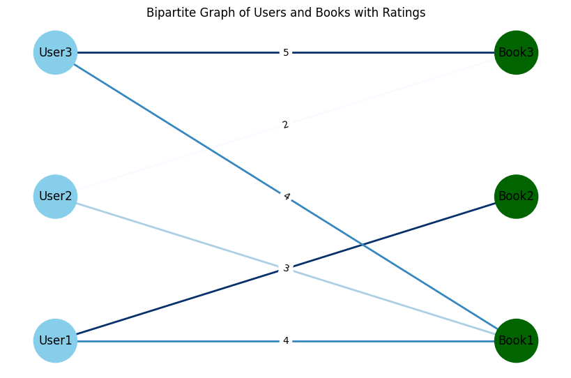

```python
import networkx as nx
import matplotlib.pyplot as plt

G = nx.Graph()


users = ['User1', 'User2', 'User3']
books = ['Book1', 'Book2', 'Book3']

G.add_nodes_from(users, bipartite=0)  # 0 to indicate one set (Users)
G.add_nodes_from(books, bipartite=1)  # 1 to indicate another set (Books)

edges = [('User1', 'Book1', 4), ('User1', 'Book2', 5),
         ('User2', 'Book1', 3), ('User2', 'Book3', 2),
         ('User3', 'Book3', 5),('User3', 'Book1', 4)]

for user, book, rating in edges:
    G.add_edge(user, book, weight=rating)

pos = nx.bipartite_layout(G, users)

plt.figure(figsize=(8, 5))
nx.draw(G, pos, with_labels=True, node_color=['skyblue' if n in users else 'darkgreen' for n in G],
        node_size=2000, edge_color=[G[u][v]['weight'] for u, v in G.edges()], width=2, edge_cmap=plt.cm.Blues)
nx.draw_networkx_edge_labels(G, pos, edge_labels={(u, v): G[u][v]['weight'] for u, v in G.edges()})
plt.title("Bipartite Graph of Users and Books with Ratings")

plt.savefig("Bipartite_Graph_Users_Books.png")

plt.show()
```

```python
# Perform a 80/20 train-test split
train, test = train_test_split(ratings.values, test_size=0.2, random_state=16)
train_df = pd.DataFrame(train, columns=ratings.columns)
test_df = pd.DataFrame(test, columns=ratings.columns)

print("Train Size  : ", len(train_df))
print("Test Size : ", len (test_df))
```

```
Train Size  :  184475
Test Size :  46119
```

Since we performed the train/test randomly on the interactions, not all users and items may be present in the training set. We will relabel all of users and items to ensure the highest label is the number of users and items, respectively.

```python
# Creating LabelEncoder objects for user_id and book_id
LabelEncoder_user = pp.LabelEncoder()
LabelEncoder_item = pp.LabelEncoder()

# Encoding user_id and book_id to numerical indices
train_df['user_id_idx'] = LabelEncoder_user.fit_transform(train_df['user_id'].values)
train_df['item_id_idx'] = LabelEncoder_item.fit_transform(train_df['book_id'].values)

# Getting unique user_ids and book_ids
train_user_ids = train_df['user_id'].unique()
train_item_ids = train_df['book_id'].unique()

# Getting the number of unique users and items
n_users = train_df['user_id_idx'].nunique()
n_items = train_df['item_id_idx'].nunique()

# Printing the number of unique users and items
print(len(train_user_ids), len(train_item_ids))
```

```
3770 5664
```

```python
# Filtering the test data to include only users and items present in the training data
test_df = test_df[
    (test_df['user_id'].isin(train_user_ids)) & \
    (test_df['book_id'].isin(train_item_ids))
]

# Printing the length of the filtered test data
print(len(test_df))

# Encoding user_id and book_id in the test data to numerical indices using the previously fitted LabelEncoders
test_df['user_id_idx'] = LabelEncoder_user.transform(test_df['user_id'].values)
test_df['item_id_idx'] = LabelEncoder_item.transform(test_df['book_id'].values)
```

```
45993
```

## Minibatch Sampling

Mini-batches are subsets of the entire dataset used for training. In this function, random users are selected, their positive interactions with items are retrieved, and negative interactions are sampled. This process helps in efficiently training the recommendation system by feeding it with diverse examples in each batch.

```python
def data_loader(data, batch_size, n_usr, n_itm):
    # Define a function to sample negative items not interacted by users
    def sample_neg(x):
        while True:
            neg_id = random.randint(0, n_itm - 1)
            if neg_id not in x:
                return neg_id

    # Group data by user_id_idx and create a list of interacted item_id_idx for each user
    interected_items_df = data.groupby('user_id_idx')['item_id_idx'].apply(list).reset_index()

    # Create a list of indices for users
    indices = [x for x in range(n_usr)]

    # Sample users for this batch
    if n_usr < batch_size:
        users = [random.choice(indices) for _ in range(batch_size)]
    else:
        users = random.sample(indices, batch_size)

    # Sort the sampled users
    users.sort()

    # Create a DataFrame of sampled users
    users_df = pd.DataFrame(users, columns=['users'])

    # Merge user interactions with sampled users
    interected_items_df = pd.merge(interected_items_df, users_df, how='right', left_on='user_id_idx', right_on='users')

    # Sample positive items for each user
    pos_items = interected_items_df['item_id_idx'].apply(lambda x: random.choice(x)).values

    # Sample negative items for each user
    neg_items = interected_items_df['item_id_idx'].apply(lambda x: sample_neg(x)).values

    # Return tensors of user indices, positive item indices, and negative item indices
    return (
        torch.LongTensor(list(users)).to(device),
        torch.LongTensor(list(pos_items)).to(device) + n_usr,
        torch.LongTensor(list(neg_items)).to(device) + n_usr
    )

# Example usage of data_loader function
data_loader(train_df, 16, n_users, n_items)
```

```
(tensor([ 712,  771,  901, 1007, 1025, 1242, 1345, 1798, 1836, 1848, 2162, 2429,
         2460, 2461, 2630, 3291]),
 tensor([4932, 3815, 6766, 4463, 4396, 4109, 4108, 4311, 3840, 3791, 4976, 3855,
         3810, 5147, 5049, 5738]),
 tensor([6030, 5065, 6717, 7475, 6132, 5068, 8236, 4458, 5785, 6604, 5019, 7844,
         9372, 8276, 5665, 7700]))
```

## Edge Index

In PyTorch Geometric (PyG), graphs are represented using sparse lists of node pairs. In our scenario of undirected graphs, each edge is duplicated to represent connections in both directions. To ensure node uniqueness, we augment the item tensor with user counts. The edge_index is constructed by combining user and book node IDs for each interaction. This creates two edge types: 'user reads/rates book' and 'book is read/rated by user,' encapsulating user-book interactions within the graph.

```python
# Convert user indices to a PyTorch LongTensor
u_t = torch.LongTensor(train_df.user_id_idx)

# Convert item indices to a PyTorch LongTensor and add the number of users to shift indices
i_t = torch.LongTensor(train_df.item_id_idx) + n_users

# Create edge indices for the training data by stacking user-item and item-user connections
train_edge_index = torch.stack((
    torch.cat([u_t, i_t]),  # Concatenate user indices and item indices
    torch.cat([i_t, u_t])   # Concatenate item indices and user indices (reversed order)
)).to(device)

# Print or return the edge indices
train_edge_index
```

```
tensor([[ 472, 2405,  660,  ..., 4746, 8853, 5653],
        [8444, 3851, 8212,  ..., 2013, 2504, 2000]])
```

## NGCF

The Neural Graph Collaborative Filtering (NGCF) model is a type of Graph Convolutional Network (GCN) applied to recommender systems. NGCF aims to enhance the recommendation quality by capturing both the collaborative signal and the user-item interactions within the graph structure.

NGCF updates the embeddings of users and items through a layer-wise propagation mechanism. For each user u and item i, their embeddings are updated as follows:

For user u:

$$e_{u}^{(k+1)} = \sigma\left(W_1 e_u^{(k)} + \sum\limits_{i \in N_u} \frac{1}{\sqrt{|N_u|}\sqrt{|N_i|}}(W_1e^{(k)}_i + W_2(e^{(k)}_i \odot e^{(k)}_u))\right)$$

For item i:

$$e_{i}^{(k+1)} = \sigma\left(W_1 e_i^{(k)} + \sum\limits_{u \in N_i} \frac{1}{\sqrt{|N_i|}\sqrt{|N_u|}}(W_1e^{(k)}_u + W_2(e^{(k)}_u \odot e^{(k)}_i))\right)$$

Here, $\mathbf{e}_u^{(k)}$ and $\mathbf{e}_i^{(k)}$ are the embeddings of user $u$ and item $i$ at the $k$-th iteration, $\mathcal{N}_u$ and $\mathcal{N}_i$ are the sets of neighbors in the graph for user $u$ and item $i$ respectively, and $\sigma$ denotes the activation function, specifically LeakyReLU in this context. $\mathbf{W}_1$ and $\mathbf{W}_2$ are trainable weight matrices that help in transforming the embeddings and capturing the interaction effects. The element-wise product $\odot$ signifies the Hadamard product, aiding in integrating the mutual influence between a user and an item.

```python
class NGCFConv(MessagePassing):
    def __init__(self, latent_dim, dropout, bias=True, **kwargs):
        super(NGCFConv, self).__init__(aggr='add', **kwargs)

        # Dropout rate
        self.dropout = dropout

        # Linear layers for message passing
        self.lin_1 = nn.Linear(latent_dim, latent_dim, bias=bias)
        self.lin_2 = nn.Linear(latent_dim, latent_dim, bias=bias)

        # Initialize parameters
        self.init_parameters()

    def init_parameters(self):
        # Initialize weights using Xavier initialization
        nn.init.xavier_uniform_(self.lin_1.weight)
        nn.init.xavier_uniform_(self.lin_2.weight)

    def forward(self, x, edge_index):
        # Compute normalization coefficients for each edge
        from_, to_ = edge_index
        deg = degree(to_, x.size(0), dtype=x.dtype)
        deg_inv_sqrt = deg.pow(-0.5)
        deg_inv_sqrt[deg_inv_sqrt == float('inf')] = 0
        norm = deg_inv_sqrt[from_] * deg_inv_sqrt[to_]

        # Start propagating messages
        out = self.propagate(edge_index, x=(x, x), norm=norm)

        # Perform update after aggregation
        out += self.lin_1(x)
        out = F.dropout(out, self.dropout, self.training)
        return F.leaky_relu(out)

    def message(self, x_j, x_i, norm):
        # Compute messages using the given normalization coefficients
        return norm.view(-1, 1) * (self.lin_1(x_j) + self.lin_2(x_j * x_i))
```

**Class Definition and Initialization**

```
class NGCFConv(MessagePassing):
    def __init__(self, latent_dim, dropout, bias=True, **kwargs):
        super(NGCFConv, self).__init__(aggr='add', **kwargs)
        self.dropout = dropout
        self.lin_1 = nn.Linear(latent_dim, latent_dim, bias=bias)
        self.lin_2 = nn.Linear(latent_dim, latent_dim, bias=bias)
        self.init_parameters()
```

`NGCFConv` extends `MessagePassing`, allowing for the implementation of the message passing scheme.

`self.lin_1` and `self.lin_2` correspond to the weight matrices $\mathbf{W}_1$ and $\mathbf{W}_2$ in the equations.

**Parameter Initialization**

```
def init_parameters(self):
    nn.init.xavier_uniform_(self.lin_1.weight)
    nn.init.xavier_uniform_(self.lin_2.weight)
```

Weights are initialized using the Xavier uniform method, which helps in the stabilization of gradients during training.

**Forward Propagation**

```
def forward(self, x, edge_index):
    from_, to_ = edge_index
    deg = degree(to_, x.size(0), dtype=x.dtype)
    deg_inv_sqrt = deg.pow(-0.5)
    deg_inv_sqrt[deg_inv_sqrt == float('inf')] = 0
    norm = deg_inv_sqrt[from_] * deg_inv_sqrt[to_]
    out = self.propagate(edge_index, x=(x, x), norm=norm)
    out += self.lin_1(x)
    out = F.dropout(out, self.dropout, self.training)
    return F.leaky_relu(out)
```

Normalization coefficients are calculated to weight the influence of each node based on its connectivity. `propagate` method handles the passing of messages between nodes, integrating neighbor embeddings.

**Message Computation**

```
def message(self, x_j, x_i, norm):
    return norm.view(-1, 1) * (self.lin_1(x_j) + self.lin_2(x_j * x_i))
```

Messages for each edge are computed using the normalization coefficients and transformations through $\mathbf{W}_1$ and $\mathbf{W}_2$. The Hadamard product $\mathbf{x}_j \odot \mathbf{x}_i$ represents interactions between the connected nodes.

## LightGCN

The Light Graph Convolutional Network (LightGCN) simplifies the Neural Graph Collaborative Filtering (NGCF) approach by eliminating weight matrices and non-linear activation functions. This makes it a streamlined model that focuses solely on neighborhood aggregation for generating user and item embeddings in recommendation systems.

\begin{equation} e_u^{(k+1)} = \sum_{i \in N_u} \frac{1}{\sqrt{|N_u|}\sqrt{|N_i|}} e_i^{(k)} \quad e_i^{(k+1)} = \sum_{u \in N_i} \frac{1}{\sqrt{|N_i|}\sqrt{|N_u|}} e_u^{(k)} \end{equation}

$N_u$: the set of all neighbors of user $u$ (items liked by $u$)

$N_i$: the set of all neighbors of item $i$ (users who liked $i$)

$e_u^{(k)}$ : k-th layer user embedding

$e_i^{(k)}$ : k-th layer item embedding

```python
class LightGCNConv(MessagePassing):
    def __init__(self, **kwargs):
        super().__init__(aggr='add')  # Initialize with summation aggregation method

    def forward(self, x, edge_index):
        # Compute normalization coefficients for each edge
        from_, to_ = edge_index
        deg = degree(to_, x.size(0), dtype=x.dtype)
        deg_inv_sqrt = deg.pow(-0.5)
        deg_inv_sqrt[deg_inv_sqrt == float('inf')] = 0
        norm = deg_inv_sqrt[from_] * deg_inv_sqrt[to_]

        # Start propagating messages (no update after aggregation)
        return self.propagate(edge_index, x=x, norm=norm)

    def message(self, x_j, norm):
        # Compute messages using the given normalization coefficients
        return norm.view(-1, 1) * x_j
```

Class Definition and Initialization

```
class LightGCNConv(MessagePassing):
    def __init__(self, **kwargs):
        super().__init__(aggr='add')
```

`LightGCNConv` uses the `MessagePassing` base class from PyTorch's geometric library, specifying an aggregation type of `add`. This indicates that messages from different nodes will be summed up.

Forward Propagation

This function calculates normalization coefficients for each edge, which are crucial for preventing scale issues due to varying node degrees.

It uses these coefficients to normalize the messages during the propagation phase. The propagation leverages the normalized adjacency matrix as the message passing pathway.

Message Computation

```
def message(self, x_j, norm):
    return norm.view(-1, 1) * x_j
```

Messages are computed as the product of the neighbor's embedding and the normalization coefficient. This aligns with the mathematical formulation, ensuring each node's influence is appropriately scaled.

LightGCN's design directly impacts the system's performance by simplifying computations and potentially enhancing interpretability. By focusing solely on the structural information from the graph via neighbor aggregation, LightGCN can effectively capture the collaborative filtering effect, making it particularly suitable for large-scale recommendation systems where efficiency is crucial.

```python
# Define the test input data
test_x = torch.Tensor(np.eye(5))
test_edge_index = torch.LongTensor(np.array([
    [0, 0, 1, 1, 2, 3, 3, 4],
    [2, 3, 3, 4, 0, 0, 1, 1]
]))

# Create an instance of LightGCNConv and pass the test data through it
output = LightGCNConv()(test_x, test_edge_index)

print(output)
```

```
tensor([[0.0000, 0.0000, 0.7071, 0.5000, 0.0000],
        [0.0000, 0.0000, 0.0000, 0.5000, 0.7071],
        [0.7071, 0.0000, 0.0000, 0.0000, 0.0000],
        [0.5000, 0.5000, 0.0000, 0.0000, 0.0000],
        [0.0000, 0.7071, 0.0000, 0.0000, 0.0000]])
```

## Recommender System GNN

The `RecSysGNN` class is a comprehensive framework tailored for building recommender systems using Graph Neural Networks (GNNs). This Python class is designed to accommodate both the NGCF and LightGCN models by stacking their convolutional layers. Below, we delve into the architecture, functionality, and specific components of the RecSysGNN class, explaining the purpose and operation of each part.

```python
class RecSysGNN(nn.Module):
  def __init__(
      self,
      latent_dim,
      num_layers,
      num_users,
      num_items,
      model, # 'NGCF' or 'LightGCN'
      dropout=0.1 # Only used in NGCF
  ):
    super(RecSysGNN, self).__init__()

    assert (model == 'NGCF' or model == 'LightGCN'), \
        'Model must be NGCF or LightGCN'
    self.model = model
    self.embedding = nn.Embedding(num_users + num_items, latent_dim)

    if self.model == 'NGCF':
      self.convs = nn.ModuleList(
        NGCFConv(latent_dim, dropout=dropout) for _ in range(num_layers)
      )
    else:
      self.convs = nn.ModuleList(LightGCNConv() for _ in range(num_layers))

    self.init_parameters()


  def init_parameters(self):
    if self.model == 'NGCF':
      nn.init.xavier_uniform_(self.embedding.weight, gain=1)
    else:
      # Authors of LightGCN report higher results with normal initialization
      nn.init.normal_(self.embedding.weight, std=0.1)


  def forward(self, edge_index):
    emb0 = self.embedding.weight
    embs = [emb0]

    emb = emb0
    for conv in self.convs:
      emb = conv(x=emb, edge_index=edge_index)
      embs.append(emb)

    out = (
      torch.cat(embs, dim=-1) if self.model == 'NGCF'
      else torch.mean(torch.stack(embs, dim=0), dim=0)
    )

    return emb0, out


  def encode_minibatch(self, users, pos_items, neg_items, edge_index):
    emb0, out = self(edge_index)
    return (
        out[users],
        out[pos_items],
        out[neg_items],
        emb0[users],
        emb0[pos_items],
        emb0[neg_items]
    )
```

Class Structure and Initialization

```
class RecSysGNN(nn.Module):
    def __init__(self, latent_dim, num_layers, num_users, num_items, model, dropout=0.1):
        super(RecSysGNN, self).__init__()
        assert (model == 'NGCF' or model == 'LightGCN'), 'Model must be NGCF or LightGCN'
        self.model = model
        self.embedding = nn.Embedding(num_users + num_items, latent_dim)
        if self.model == 'NGCF':
            self.convs = nn.ModuleList(NGCFConv(latent_dim, dropout=dropout) for _ in range(num_layers))
        else:
            self.convs = nn.ModuleList(LightGCNConv() for _ in range(num_layers))
        self.init_parameters()
```

The `RecSysGNN` class inherits from `nn.Module` and initializes embeddings for users and items combined. The model allows selection between 'NGCF' and 'LightGCN'.

For NGCF, dropout is an additional parameter that provides regularization.

The convolutional layers (`convs`) are set up based on the chosen model. The use of `nn.ModuleList` allows stacking multiple layers, which enables the diffusion of information across multiple hops in the graph.

Parameter Initialization

```
def init_parameters(self):
    if self.model == 'NGCF':
        nn.init.xavier_uniform_(self.embedding.weight, gain=1)
    else:
        nn.init.normal_(self.embedding.weight, std=0.1)
```

Different initialization strategies are used for the embeddings based on the model. NGCF uses Xavier uniform initialization to maintain variance across layers, while LightGCN uses normal initialization, recommended for its simplicity and performance.

Forward Propagation

```
def forward(self, edge_index):
    emb0 = self.embedding.weight
    embs = [emb0]
    emb = emb0
    for conv in self.convs:
        emb = conv(x=emb, edge_index=edge_index)
        embs.append(emb)
    out = (torch.cat(embs, dim=-1) if self.model == 'NGCF' else torch.mean(torch.stack(embs, dim=0), dim=0))
    return emb0, out
```

The `forward` method propagates embeddings across all nodes in the graph simultaneously, considering the entire n-hop neighborhood.

The embeddings are updated layer by layer. The final output can be either a concatenation (NGCF) or an average (LightGCN) of all layer embeddings. This difference reflects the distinct propagation styles of the two models.

Minibatch Embedding Encoding

```
def encode_minibatch(self, users, pos_items, neg_items, edge_index):
    emb0, out = self(edge_index)
    return (out[users], out[pos_items], out[neg_items], emb0[users], emb0[pos_items], emb0[neg_items])
```

This function retrieves specific embeddings for users, positive items, and negative items from a minibatch, essential for training sessions that involve personalized recommendations or triplet loss calculations.

The `RecSysGNN` class is engineered to handle the dynamics of graph-based recommendation systems effectively, leveraging the strengths of GNNs to model user-item interactions comprehensively. This approach allows the model to capture complex patterns and relationships within the data, potentially leading to more accurate and personalized recommendations.

## Loss function and metrics

The `RecSysGNN` class, designed for recommendation systems using GNNs like NGCF and LightGCN, employs a Bayesian Personalized Ranking (BPR) loss function to enhance recommendation accuracy by favoring positive item interactions over negative ones for each user. Additionally, the system uses evaluation metrics such as precision@K and recall@K to measure its effectiveness. Here, I'll explain the implementation of the BPR loss function and the evaluation metrics in more detail.

Bayesian Personalized Ranking (BPR) Loss The BPR loss is a pairwise ranking loss, which is widely used in recommendation systems to ensure that the predicted scores of items that a user interacts with (positive samples) are higher than those of items the user has not interacted with (negative samples). The mathematical formulation is given by:

\begin{equation} L_{BPR} = -\sum_{u = 1}^M \sum_{i \in N_u} \sum_{j \notin N_u} \ln{\sigma(\hat{y}_{ui} - \hat{y}_{uj})} + \lambda ||E^{(0)}||^2 \end{equation}

$\hat{y}_{u}$: predicted score of a positive sample

$\hat{y}_{uj}$: predicted score of a negative sample

$\lambda$: hyperparameter which controls the L2 regularization strength

```python
def compute_bpr_loss(users, users_emb, pos_emb, neg_emb, user_emb0,  pos_emb0, neg_emb0):
    # Compute regularization loss from initial embeddings
    reg_loss = (1 / 2) * (
        user_emb0.norm().pow(2) +  # L2 norm of user embeddings
        pos_emb0.norm().pow(2) +    # L2 norm of positive item embeddings
        neg_emb0.norm().pow(2)      # L2 norm of negative item embeddings
    ) / float(len(users))  # Normalize by the number of users

    # Compute Bayesian Personalized Ranking (BPR) loss from user, positive item, and negative item embeddings
    pos_scores = torch.mul(users_emb, pos_emb).sum(dim=1)  # Dot product of user and positive item embeddings
    neg_scores = torch.mul(users_emb, neg_emb).sum(dim=1)  # Dot product of user and negative item embeddings

    # Compute BPR loss as the mean of the softplus function applied to the differences between negative and positive scores
    bpr_loss = torch.mean(F.softplus(neg_scores - pos_scores))

    return bpr_loss, reg_loss
```

```
def compute_bpr_loss(users, users_emb, pos_emb, neg_emb, user_emb0, pos_emb0, neg_emb0):
    # Regularization term
    reg_loss = (1 / 2) * (
        user_emb0.norm().pow(2) +
        pos_emb0.norm().pow(2) +
        neg_emb0.norm().pow(2)
    ) / float(len(users))

    # BPR loss calculation
    pos_scores = torch.mul(users_emb, pos_emb).sum(dim=1)
    neg_scores = torch.mul(users_emb, neg_emb).sum(dim=1)
    bpr_loss = torch.mean(F.softplus(neg_scores - pos_scores))

    return bpr_loss + reg_loss
```

Regularization Loss: Computed as the half norm squared of the initial embeddings, scaled by the number of users to avoid overfitting.

BPR Loss: Uses the `softplus` function to smoothly penalize instances where negative samples score higher than positive ones.

#### Evaluation Metrics (Precision@K and Recall@K)

To assess the model's performance, precision and recall are calculated for the top K recommendations made by the system.

Precision@K: Measures the proportion of recommended items in the top K set that are relevant.

Recall@K: Measures the proportion of relevant items that are captured by the top K recommendations.

Relevance Score Calculation: A matrix multiplication between user and item embeddings to calculate scores for all possible interactions.

Interaction Masking: Masks the scores for interactions already present in the training set to focus only on potential new recommendations.

Metric Calculation: Determines how many of the top K recommendations are actual interactions in the test set.

Together, these methods provide a robust mechanism for training and evaluating recommendation models, ensuring that the recommendations are both accurate and relevant.

```python
def get_metrics(user_Embed_wts, item_Embed_wts, n_users, n_items, train_data, test_data, K):
    # Get unique user IDs from the test data
    test_user_ids = torch.LongTensor(test_data['user_id_idx'].unique())

    # Compute the score of all user-item pairs
    relevance_score = torch.matmul(user_Embed_wts, torch.transpose(item_Embed_wts, 0, 1))

    # Create dense tensor of all user-item interactions
    i = torch.stack((
        torch.LongTensor(train_df['user_id_idx'].values),
        torch.LongTensor(train_df['item_id_idx'].values)
    ))
    v = torch.ones((len(train_df)), dtype=torch.float64)
    interactions_t = torch.sparse.FloatTensor(i, v, (n_users, n_items))\
        .to_dense().to(device)

    # Mask out training user-item interactions from metric computation
    relevance_score = torch.mul(relevance_score, (1 - interactions_t))

    # Compute top scoring items for each user
    topk_relevance_indices = torch.topk(relevance_score, K).indices
    topk_relevance_indices_df = pd.DataFrame(topk_relevance_indices.cpu().numpy(),
                                              columns=['top_indx_' + str(x + 1) for x in range(K)])
    topk_relevance_indices_df['user_ID'] = topk_relevance_indices_df.index
    topk_relevance_indices_df['top_rlvnt_itm'] = topk_relevance_indices_df[
        ['top_indx_' + str(x + 1) for x in range(K)]].values.tolist()
    topk_relevance_indices_df = topk_relevance_indices_df[['user_ID', 'top_rlvnt_itm']]

    # Measure overlap between recommended (top-scoring) and held-out user-item interactions
    test_interacted_items = test_data.groupby('user_id_idx')['item_id_idx'].apply(list).reset_index()
    metrics_df = pd.merge(test_interacted_items, topk_relevance_indices_df, how='left', left_on='user_id_idx',
                          right_on=['user_ID'])
    metrics_df['intrsctn_itm'] = [list(set(a).intersection(b)) for a, b in
                                   zip(metrics_df.item_id_idx, metrics_df.top_rlvnt_itm)]

    # Compute recall and precision
    metrics_df['recall'] = metrics_df.apply(lambda x: len(x['intrsctn_itm']) / len(x['item_id_idx']), axis=1)
    metrics_df['precision'] = metrics_df.apply(lambda x: len(x['intrsctn_itm']) / K, axis=1)

    return metrics_df['recall'].mean(), metrics_df['precision'].mean()
```

## Train and evaluate models

Now that we've implemented both LightGCN and NGCF in PyG, we can train and evaluate their performance!

```python
latent_dim = 64
n_layers = 3

EPOCHS = 50
BATCH_SIZE = 1024
DECAY = 0.0001
LR = 0.005
K = 20
```

```python
def train_and_eval(model, optimizer, train_df):
    # Initialize lists to store losses and evaluation metrics
    loss_list_epoch = []
    bpr_loss_list_epoch = []
    reg_loss_list_epoch = []
    recall_list = []
    precision_list = []

    # Iterate over epochs
    for epoch in tqdm(range(EPOCHS)):
        n_batch = int(len(train) / BATCH_SIZE)  # Compute the number of batches

        final_loss_list = []
        bpr_loss_list = []
        reg_loss_list = []

        model.train()  # Set the model to training mode
        # Iterate over batches
        for batch_idx in range(n_batch):
            optimizer.zero_grad()  # Zero gradients
            # Load data for the batch
            users, pos_items, neg_items = data_loader(train_df, BATCH_SIZE, n_users, n_items)
            # Encode minibatch
            users_emb, pos_emb, neg_emb, userEmb0,  posEmb0, negEmb0 = model.encode_minibatch(users, pos_items, neg_items, train_edge_index)

            # Compute BPR loss and regularization loss
            bpr_loss, reg_loss = compute_bpr_loss(
                users, users_emb, pos_emb, neg_emb, userEmb0,  posEmb0, negEmb0
            )
            reg_loss = DECAY * reg_loss  # Apply decay to regularization loss
            final_loss = bpr_loss + reg_loss  # Total loss

            final_loss.backward()  # Backpropagation
            optimizer.step()  # Optimization step

            # Append losses to the respective lists
            final_loss_list.append(final_loss.item())
            bpr_loss_list.append(bpr_loss.item())
            reg_loss_list.append(reg_loss.item())

        # Evaluation phase
        model.eval()  # Set the model to evaluation mode
        with torch.no_grad():
            # Get final user and item embeddings
            _, out = model(train_edge_index)
            final_user_Embed, final_item_Embed = torch.split(out, (n_users, n_items))
            # Compute recall and precision metrics
            test_topK_recall,  test_topK_precision = get_metrics(
                final_user_Embed, final_item_Embed, n_users, n_items, train_df, test_df, K
            )

        # Append epoch-wise losses and evaluation metrics to respective lists
        loss_list_epoch.append(round(np.mean(final_loss_list), 4))
        bpr_loss_list_epoch.append(round(np.mean(bpr_loss_list), 4))
        reg_loss_list_epoch.append(round(np.mean(reg_loss_list), 4))
        recall_list.append(round(test_topK_recall, 4))
        precision_list.append(round(test_topK_precision, 4))

    return (
        loss_list_epoch,
        bpr_loss_list_epoch,
        reg_loss_list_epoch,
        recall_list,
        precision_list
    )
```

```python
### Train and eval LightGCN
lightgcn = RecSysGNN(
  latent_dim=latent_dim,
  num_layers=n_layers,
  num_users=n_users,
  num_items=n_items,
  model='LightGCN'
)
lightgcn.to(device)

optimizer = torch.optim.Adam(lightgcn.parameters(), lr=LR)
print("Size of Learnable Embedding : ", [x.shape for x in list(lightgcn.parameters())])
```

```
Size of Learnable Embedding :  [torch.Size([9434, 64])]
```

```python
light_loss, light_bpr, light_reg, light_recall, light_precision = train_and_eval(lightgcn, optimizer, train_df)
```

```python
epoch_list = [(i+1) for i in range(EPOCHS)]
```

## Result

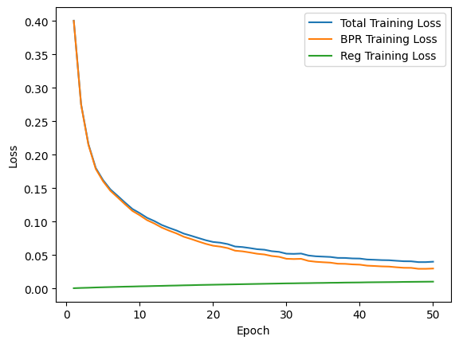

```python
plt.plot(epoch_list, light_loss, label='Total Training Loss')
plt.plot(epoch_list, light_bpr, label='BPR Training Loss')
plt.plot(epoch_list, light_reg, label='Reg Training Loss')

plt.xlabel('Epoch')
plt.ylabel('Loss')
plt.legend()
plt.savefig('light_loss.png')
```

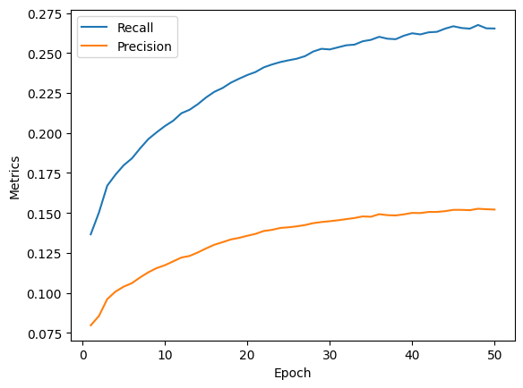

```python
plt.plot(epoch_list, light_recall, label='Recall')
plt.plot(epoch_list, light_precision, label='Precision')
plt.xlabel('Epoch')
plt.ylabel('Metrics')
plt.legend()
plt.savefig('light_recall.png')
```

```python
### Train and eval NGCF
ngcf = RecSysGNN(
  latent_dim=latent_dim,
  num_layers=n_layers,
  num_users=n_users,
  num_items=n_items,
  model='NGCF'
)
ngcf.to(device)

optimizer = torch.optim.Adam(ngcf.parameters(), lr=LR)
print("Size of Learnable Embedding : ", [x.shape for x in list(ngcf.parameters())])
```

```
Size of Learnable Embedding :  [torch.Size([9434, 64]), torch.Size([64, 64]), torch.Size([64]), torch.Size([64, 64]), torch.Size([64]), torch.Size([64, 64]), torch.Size([64]), torch.Size([64, 64]), torch.Size([64]), torch.Size([64, 64]), torch.Size([64]), torch.Size([64, 64]), torch.Size([64])]
```

```python
ngcf_loss, ngcf_bpr, ngcf_reg, ngcf_recall, ngcf_precision = train_and_eval(ngcf, optimizer, train_df)
```

```python
epoch_list = [(i+1) for i in range(EPOCHS)]
```

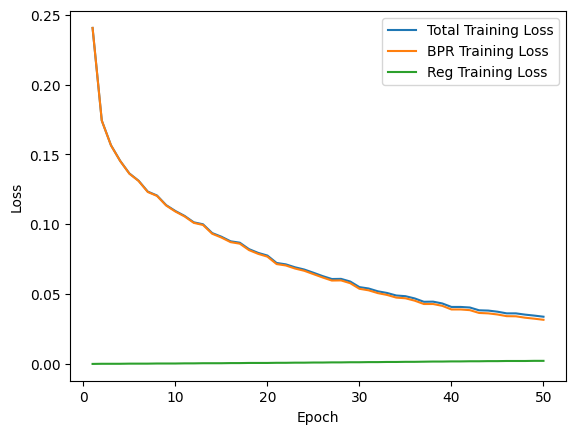

```python
plt.plot(epoch_list, ngcf_loss, label='Total Training Loss')
plt.plot(epoch_list, ngcf_bpr, label='BPR Training Loss')
plt.plot(epoch_list, ngcf_reg, label='Reg Training Loss')

plt.xlabel('Epoch')
plt.ylabel('Loss')
plt.legend()
plt.savefig('ngcf_loss.png')
```

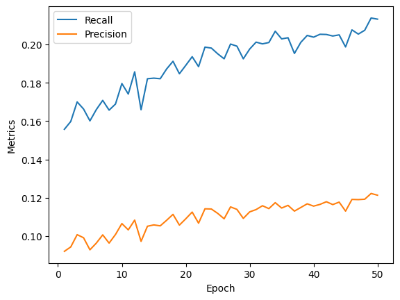

```python
plt.plot(epoch_list, ngcf_recall, label='Recall')
plt.plot(epoch_list, ngcf_precision, label='Precision')
plt.xlabel('Epoch')
plt.ylabel('Metrics')
plt.legend()
plt.savefig('ngcf_recall.png')
```

```python
max(light_precision), max(light_recall)
```

```
(0.1526, 0.2675)
```

```python
max(ngcf_precision), max(ngcf_recall)
```

```
(0.1222, 0.2138)
```

Based on the results, we observe distinct differences in the performance of NGCF and LightGCN models. Despite both models being trained using the same minibatching procedure on an 80/20 train-test split, LightGCN exhibits smoother $\text{precision@20}$ and $\text{recall@20}$ curves compared to NGCF.

The analysis of the loss graphs shows a rapid decline in total training loss for both models, indicating that each model is learning effectively from the training data. The Bayesian Personalized Ranking (BPR) loss, which focuses on the order of recommendations, shows a significant decrease, reinforcing that both models are enhancing their ranking capabilities as training progresses. Additionally, the regularization loss remains consistently low, which is indicative of effective control over model complexity and avoidance of overfitting.

These observations suggest that LightGCN may have a better mechanism for capturing and utilizing the graph structure of the data compared to NGCF. This leads to superior performance in terms of both identifying the correct items (recall) and in the accuracy of these identifications (precision). LightGCN's more effective learning and prediction capabilities make it a preferable choice for tasks where higher precision and recall are crucial.

## Future Work

In the final project, we outline a comprehensive approach to building a book recommender system utilizing advanced techniques such as Graph Neural Networks (GNNs). Our system currently incorporates models like LightGCN and NGCF, which excel in capturing user-item interactions for recommendation purposes. Looking towards future enhancements, we aim to integrate the Knowledge Graph Attention Network (KGAT) architecture. KGAT offers a sophisticated method to leverage side information encoded as knowledge graphs, enabling more nuanced, diverse, and explainable recommendations. By incorporating entity features such as directors, cast, and genre, our system can better profile items, enhancing recommendation quality. Additionally, we recognize the significance of considering seasonality and session-based interactions for refined recommendations. Strategies such as training on recent transactions and weighting recent interactions more heavily based on the time elapsed can ensure our system recommends relevant items tailored to current trends. Furthermore, exploring session-based recommender systems like SR-GNN and TAGNN could empower our system to infer user interests from short interaction patterns, improving engagement with new customers. By integrating these advancements, we anticipate significant enhancements in the performance and user experience of our book recommender system.

```python
!jupyter nbconvert e104_IsikTopbas_Arzu_Final_Project.ipynb --to html --embed-images
```

```
[NbConvertApp] Converting notebook e104_IsikTopbas_Arzu_Final_Project.ipynb to html
[NbConvertApp] WARNING | Alternative text is missing on 5 image(s).
[NbConvertApp] Writing 649529 bytes to e104_IsikTopbas_Arzu_Final_Project.html
```